← Eğitim Listesine Geri Dön

# Bağımlı İki Örneklem T-Testi

2025-06-08

paired t-test öncesi-sonrası eşleştirilmiş test

# 🧪 Bağımlı İki Örneklem T Testi: Aynı Kişi Üzerinde Değişim Ölçmek

## Giriş: Bir Müdahale Gerçekten Etkili mi?

Diyelim ki yeni bir ilacı denedin.  
Kan basıncını düşürdüğünü iddia ediyorlar.  
Ama bu etki gerçekten var mı?

> “Bağımlı t-testi, aynı kişi veya nesne üzerinde değişimi ölçmenin yolu olur.

Önce neydi, sonra ne oldu → işte gerçek fark burada.”

## 🔍 Bağımlı İki Örneklem T-Testi Nedir?

Bu test, **aynı bireylerdeki ölçümlerin öncesi ile sonrası arasında fark var mı?** diye sorar.

📌 Genellikle:

- Eğitim programları
- İlaç etkileri
- Reklam kampanyası sonuçları
- Kullanıcı deneyimi testleri

📌 Örneğin:

- Kullanıcılar önce ortalama 7 puan verdi, sonra 8.5 puan → bu fark anlamlı mı?

## 📐 Formülü:

$$ t = \frac{\bar{d} - \mu_d}{\frac{s_d}{\sqrt{n}}} $$

| Sembol | Açıklama |
| --- | --- |
| $\bar{d}$ | Farkların ortalaması |
| $\mu_d$ | Popülasyon fark ortalaması (genelde 0 alınır) |
| $s_d$ | Farkların standart sapması |
| $n$ | Birey sayısı |

📌 Serbestlik derecesi: `df = n - 1`

# Bağımlı İki Örneklem T Testi

## **Bağımlı İki Örneklem T-testi**

Bağımlı iki grup ortalaması arasında karşılaştırma yapılmak istenildiğinde kullanılır.

Bağımlı iki örneklem t-testi (Paired Sample t-test veya Dependent Sample t-test), aynı bireyler veya nesneler üzerinde iki farklı koşul altında alınan örneklem verileri arasında istatistiksel olarak anlamlı bir fark olup olmadığını değerlendiren bir hipotez testidir.

Bu test, örneklem verilerinin normal dağıldığı ve verilerin birbirinden bağımsız olmadığı durumlar için kullanılır. Bağımlı iki örneklem t-testi, genellikle aynı bireyler üzerinde yapılan bir müdahalenin (tedavi, eğitim vb.) öncesi ve sonrası durumlarını karşılaştırmak için kullanılır.

Paired Samples t-test, Eşleştirilmiş Örneklem t Testi veya İlişkili Örneklem t Testi olarak da bilinir; aynı denekler üzerinde iki farklı zamanda veya iki farklı koşul altında yapılan ölçümlerin ortalamaları arasında istatistiksel olarak anlamlı bir fark olup olmadığını belirlemek için kullanılan bir parametrik testtir. "Bağımlı" terimi, iki örneklem grubunun birbiriyle ilişkili olduğunu, yani her bir gözlemin bir eşi olduğunu ifade eder. Bu test, özellikle aynı grubun ön test ve son test sonuçlarını karşılaştırmak, aynı denek üzerinde iki farklı uygulamanın etkisini ölçmek veya eşleştirilmiş denek gruplarını karşılaştırmak gerektiğinde kullanılır.

**Bağımlı İki Örneklem T Testi Ne Zaman Kullanılır?**

- Aynı denekler üzerinde iki farklı zamanda (ön test-son test gibi) yapılan ölçümleri karşılaştırmak istediğinizde. Örneğin, bir eğitim programının öğrencilerin bilgi düzeyleri üzerindeki etkisini ölçmek için program öncesi ve sonrası yapılan test sonuçlarını karşılaştırmak gibi.
- Aynı denek üzerinde iki farklı koşul altında yapılan ölçümleri karşılaştırmak istediğinizde. Örneğin, bir ilacın aynı kişilerde farklı dozlarda nasıl etki ettiğini ölçmek gibi.
- Eşleştirilmiş denek gruplarını karşılaştırmak istediğinizde. Örneğin, genetik olarak benzer farelerin farklı diyetlerle beslenmesi sonucu oluşan kilo farklarını karşılaştırmak gibi.
- Örneklem büyüklüğü küçük olduğunda (genellikle n < 30) ve popülasyon standart sapması bilinmediğinde.
- Verilerin normal dağılıma yakın olduğu varsayıldığında.

**Bağımlı İki Örneklem T Testinin Varsayımları:**

- **Bağımlılık:** Her bir gözlemin bir eşi olmalıdır. Yani, iki örneklem grubu arasında birebir eşleşme olmalıdır.
- **Normallik:** Fark puanlarının (iki ölçüm arasındaki fark) popülasyonda normal dağılıma sahip olması varsayılır. Ancak, örneklem büyüklüğü yeterince büyükse (genellikle n > 30), bu varsayımın ihlali testin sonuçlarını önemli ölçüde etkilemeyebilir (Merkezi Limit Teoremi).
- **Sürekli Veri:** Ölçülen değişken sürekli veri tipinde olmalıdır (örneğin, puan, kilo, kan basıncı).

## **Testin hipotezleri şu şekildedir:**

## $t = \frac{\bar{d} - \mu_d}{\frac{s_d}{\sqrt{n}}}$

Burada:

- $t $: Test istatistiği
- $ \bar{d} $: İki örnek arasındaki farkın ortalaması
- $ \mu_d $: Popülasyondaki farkın teorik ortalaması (genellikle sıfır olarak alınır, çünkü H0 hipotezi genellikle "iki durum arasında bir fark yoktur" şeklindedir.)
- $s_d $: İki örnek arasındaki farkların standart sapması
- $n$: Örneklemin büyüklüğü

Bu formülde, $t $ test istatistiği, iki örnek arasındaki farkın örnek ortalaması $ \bar{d} $ ile farkın popülasyon ortalaması $ \mu_d $ arasındaki farkın standart hata ${\frac{s_d}{\sqrt{n}}}$ oranıdır.

Bu test istatistiği daha sonra belirli bir anlamlılık düzeyinde (genellikle 0.05) karar vermek için t-dağılım tablosu kullanılarak karşılaştırılır. Eğer test istatistiği, t-dağılım tablosundaki kritik değerden büyükse, H0 hipotezi reddedilir ve iki durum arasında anlamlı bir fark olduğu sonucuna varılır.

- **Null Hypothesis (H0):** İki koşul arasında herhangi bir fark yoktur.
- **Alternative Hypothesis (H1):** İki koşul arasında istatistiksel olarak anlamlı bir fark vardır.

Bu testin sonucunda elde edilen t istatistiği ve p değeri, null hipotezin reddedilip edilemeyeceğini belirler. Düşük bir p değeri (genellikle 0.05'ten küçük) null hipotezin reddedilmesi için yeterli kanıt olarak kabul edilir, bu da iki koşul arasında bir fark olduğunu gösterir.

**Bağımlı İki Örneklem T Testi Nasıl Yapılır?**

1. **Sıfır Hipotezi (H₀) ve Alternatif Hipotezi (H₁) Belirleyin:**
   - H₀: İki ölçüm arasında ortalama fark yoktur (μd = 0). Burada μd, fark puanlarının ortalamasıdır.
   - H₁: İki ölçüm arasında ortalama fark vardır (μd ≠ 0) (İki yönlü test). Veya, bir ölçüm diğerinden büyüktür (μd > 0 veya μd < 0) (Tek yönlü test).
2. **Anlamlılık Düzeyini (α) Belirleyin:** Genellikle α = 0.05 kullanılır.
3. **Fark Puanlarını Hesaplayın:** Her bir denek için iki ölçüm arasındaki farkı hesaplayın (d = X₁ - X₂).
4. **Fark Puanlarının Ortalamasını (d̄) ve Standart Sapmasını (sd) Hesaplayın:**
5. **T İstatistiğini Hesaplayın:**

   ```
   t = d̄ / (sd / √n)
   ```

   Burada:
   - d̄: Fark puanlarının ortalaması
   - sd: Fark puanlarının standart sapması
   - n: Örneklem büyüklüğü (denek sayısı)
6. **Serbestlik Derecesini (sd) Hesaplayın:**

   sd = n - 1
7. **Kritik T Değerini Bulun:** T dağılım tablosundan veya istatistiksel yazılımdan, belirlenen anlamlılık düzeyi (α) ve serbestlik derecesi (sd) ile kritik t değerini bulunur.
8. **Karar Verin:**
   - Eğer hesaplanan t istatistiğinin mutlak değeri, kritik t değerinden büyükse, sıfır hipotezi reddedilir. Bu, iki ölçüm arasında istatistiksel olarak anlamlı bir fark olduğu anlamına gelir.
   - Eğer hesaplanan t istatistiğinin mutlak değeri, kritik t değerinden küçükse, sıfır hipotezi reddedilmez.

## 🧠 Neden Önemlidir?

| Sebep | Açıklama |
| --- | --- |
| ✅ **Aynı kişi üzerinden değişimi ölçer** | Aykırı değerlerden daha az etkilenir |
| ✅ **Daha güçlü istatistiksel test sunar** | Varyans kontrolü sayesinde |
| ✅ **Modelleme sürecinde kullanılır** | Zaman içinde değişimi modellemek için |
| ✅ **AB testinden farklıdır** | Bu test eşleştirilmiş veriyle yapılır |

📌 AB testi → bağımsız gruplar  
Paired t-testi → aynı kişiler üzerinde

## 🛠️ Adım Adım Uygulama: Gerçek Hayat Senaryosu

### Örnek:

Bir ilaç firması yeni bir kan basıncı ilacı test ediyor.  
20 hasta üzerinde, ilacın kullanımı öncesi ve sonrası sistolik kan basıncı ölçülüyor.

#### Soru:

İlacın kan basıncını düşürdüğüne dair istatistiksel kanıtımız var mı?

### Adım 1: Hipotez Kurulumu

```
print("H₀: Ortalama fark sıfırdır → ilacın etkisi yok")
print("H₁: Ortalama fark sıfırdan farklıdır → ilacın etkisi var")
```

✅ Null hipotezi → fark yok  
Alternatif → fark var

```python
# Adım 2: Anlamlılık Düzeyini Belirle

alpha = 0.05
print(f"Anlamlılık düzeyi (α): {alpha}")

# %5 yanılma payı kabul ettik.
```

```
Anlamlılık düzeyi (α): 0.05
```

```python
# Adım 3:sample veri üret

import numpy as np

np.random.seed(42)
n = 20

# Öncesi ve sonrası veriler
kan_basinci_oncesi = np.random.normal(loc=140, scale=10, size=n)
kan_basinci_sonrasi = kan_basinci_oncesi - np.random.normal(loc=10, scale=5, size=n)

print("Ortalama Kan Basıncı Öncesi:", kan_basinci_oncesi.mean().round(2))
print("Ortalama Kan Basıncı Sonrası:", kan_basinci_sonrasi.mean().round(2))
```

```
Ortalama Kan Basıncı Öncesi: 138.29
Ortalama Kan Basıncı Sonrası: 129.62
```

```python
# Adım 4: Farkları Hesapla

farklar = kan_basinci_oncesi - kan_basinci_sonrasi
print("Farkların Ortalaması:", farklar.mean().round(2))
print("Farkların Standart Sapması:", farklar.std().round(2))

#Artık farklar üzerinden test yapabiliriz.
```

```
Farkların Ortalaması: 8.67
Farkların Standart Sapması: 4.72
```

```python
# Adım 5: Paired T-Testi Yap

from scipy.stats import ttest_rel

t_skoru, p_degeri = ttest_rel(kan_basinci_oncesi, kan_basinci_sonrasi)
print(f"T Skoru: {t_skoru:.2f}, p-değeri: {p_degeri:.4f}")
```

```
T Skoru: 8.01, p-değeri: 0.0000
```

```python
# Adım 6: Karar Ver


if p_degeri < alpha:
    print("✅ H₀ reddedildi → İlacın etkisi var")
else:
    print("❌ H₀ reddedilemedi → Etki tesadüfi olabilir")


# Yani ilacın kan basıncını düşürdüğünü sayılarla kanıtlanıyor.
```

```
✅ H₀ reddedildi → İlacın etkisi var
```

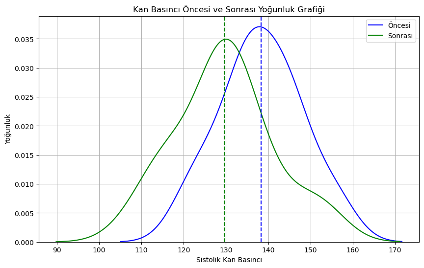

```python
# 📈 Görselleştirme: Öncesi ve Sonrası

import matplotlib.pyplot as plt
import seaborn as sns

plt.figure(figsize=(10, 6))
sns.kdeplot(kan_basinci_oncesi, label="Öncesi", color='blue')
sns.kdeplot(kan_basinci_sonrasi, label="Sonrası", color='green')

plt.axvline(kan_basinci_oncesi.mean(), color='blue', linestyle='--')
plt.axvline(kan_basinci_sonrasi.mean(), color='green', linestyle='--')

plt.title("Kan Basıncı Öncesi ve Sonrası Yoğunluk Grafiği")
plt.xlabel("Sistolik Kan Basıncı")
plt.ylabel("Yoğunluk")
plt.grid(True)
plt.legend()
plt.show()
```

📌 Bu grafikte:

- Mavi çizgi → öncesi
- Yeşil çizgi → sonrası

```python
# 📊 Python Kodu ile Tekrarlanabilir Test

_, p_val = ttest_rel(kan_basinci_oncesi, kan_basinci_sonrasi)
print(f"A/B Testi p-değeri: {p_val:.6f}")
```

```
A/B Testi p-değeri: 0.000000
```

## 📉 Varsayımlar Ne?

| Varsayım | Açıklama | Python ile Nasıl Test Edilir? |
| --- | --- | --- |
| **Bağımlılık** | Aynı bireylerde iki ölçüm → sağlanıyor | Deney tasarımıyla sağlanır |
| **Normallik** | Farklar normal dağılmalı | Shapiro-Wilk testi |
| **Sürekli veri** | Sayısal ölçümler olmalı | Evet, kan basıncı sürekli veri |

📌 Normallik sağlanmıyorsa → Wilcoxon İşaretli Sıra testi kullanılır.

### Shapiro-Wilk ile Normallik Kontrolü

```python
from scipy.stats import shapiro

stat, p = shapiro(farklar)
print(f"Shapiro-Wilk p-değeri: {p:.4f}")

if p > alpha:
    print("✅ Farklar normal dağılıyor")
else:
    print("❌ Farklar normal değil → Nonparametrik test düşünülmeli")
```

```
Shapiro-Wilk p-değeri: 0.7676
✅ Farklar normal dağılıyor
```

## 📌 Bağımlı T-Testi ve Modelleme Süreci Bağlantısı

| Alan | Açıklama |
| --- | --- |
| **Sağlık** | Tedavinin etkisini öncesi/sonrası karşılaştırmak için |
| **Eğitim** | Eğitim öncesi ve sonrası başarı oranlarını karşılamak için |
| **Pazarlama** | Kampanya öncesi ve sonrası satışları karşılamak için |
| **Veri Bilimi** | Özelliklerin zaman içindeki değişimini analiz etmek için |

📌 Özellikle zamana bağlı verilerde güçlü bir araçtır.

**Örnek:**

Bir diyet programının kilo verme üzerindeki etkisini ölçmek için bir araştırma yapılıyor. 10 kişi programa başlamadan önce ve program bittikten sonra tartılıyor. Kilo değişimleri aşağıdaki gibi olsun:

| Kişi | Başlangıç Kilosu (X₁) | Bitiş Kilosu (X₂) | Fark (d = X₁ - X₂) |
| --- | --- | --- | --- |
| 1 | 80 | 75 | 5 |
| 2 | 90 | 82 | 8 |
| 3 | 75 | 70 | 5 |
| 4 | 85 | 80 | 5 |
| 5 | 70 | 68 | 2 |
| 6 | 95 | 88 | 7 |
| 7 | 65 | 62 | 3 |
| 8 | 100 | 92 | 8 |
| 9 | 78 | 72 | 6 |
| 10 | 82 | 77 | 5 |

Bu verilerle Bağımlı İki Örneklem T Testi yapalım (α = 0.05):

4. **Serbestlik Derecesi:**

   sd = 10 - 1 = 9
5. **Kritik T Değeri:**

   α = 0.05 ve sd = 9 için tek yönlü t tablosundan kritik t değeri yaklaşık olarak 1.833 olarak bulunur.
6. **Karar:**

```python
import numpy as np
from scipy import stats

# Verilerin tanımlanması
baslangic = np.array([80, 90, 75, 85, 70, 95, 65, 100, 78, 82])
bitis = np.array([75, 82, 70, 80, 68, 88, 62, 92, 72, 77])

# Bağımlı iki örneklem t testi (paired t-test)
t_statistic, p_value = stats.ttest_rel(baslangic, bitis)

# Tek yönlü test için p değerinin yarısını alıyoruz (H1: μd > 0)
p_value_one_tailed = p_value / 2
```

```python
# Sonuçların yazdırılması
print("Bağımlı İki Örneklem T Testi Sonuçları:")
print(f"T istatistiği: {t_statistic:.4f}")
print(f"P değeri (tek yönlü): {p_value_one_tailed:.6f}")
```

```
Bağımlı İki Örneklem T Testi Sonuçları:
T istatistiği: 8.7345
P değeri (tek yönlü): 0.000005
```

```python
# Kritik t değerinin hesaplanması
alpha = 0.05
degrees_of_freedom = len(baslangic) - 1
critical_t = stats.t.ppf(1 - alpha, degrees_of_freedom)
print(f"Kritik t değeri (α=0.05, tek yönlü): {critical_t:.4f}")
```

```
Kritik t değeri (α=0.05, tek yönlü): 1.8331
```

```python
# Karar kuralı
if t_statistic > critical_t:
    print("Sonuç: H0 reddedilir - Diyetin kilo verme üzerinde anlamlı bir etkisi vardır.")
else:
    print("Sonuç: H0 reddedilemez - Diyetin kilo verme üzerinde anlamlı bir etkisi yoktur.")
```

```
Sonuç: H0 reddedilir - Diyetin kilo verme üzerinde anlamlı bir etkisi vardır.
```

```python
# Ek bilgiler
farklar = baslangic - bitis
print("\nEk Bilgiler:")
print(f"Farkların ortalaması: {np.mean(farklar):.2f}")
print(f"Farkların standart sapması: {np.std(farklar, ddof=1):.2f}")
print(f"Örneklem büyüklüğü: {len(baslangic)}")
```

```
Ek Bilgiler:
Farkların ortalaması: 5.40
Farkların standart sapması: 1.96
Örneklem büyüklüğü: 10
```

# Adım adım görmek istersek:

```python
# bağımlı iki örneklem t-testi (paired samples t-test) için adım adım python kod:
import numpy as np
from scipy import stats

# Veriler
baslangic = np.array([80, 90, 75, 85, 70, 95, 65, 100, 78, 82])
bitis = np.array([75, 82, 70, 80, 68, 88, 62, 92, 72, 77])

# 1. Farkların hesaplanması
farklar = baslangic - bitis

# 2. Tanımlayıcı istatistikler
ortalama_fark = np.mean(farklar)
std_fark = np.std(farklar, ddof=1)  # ddof=1 ile örneklem standart sapması
n = len(farklar)

print("--- Tanımlayıcı İstatistikler ---")
print(f"Ortalama Fark (Başlangıç - Bitiş): {ortalama_fark:.2f} kg")
print(f"Standart Sapma: {std_fark:.2f} kg")
print(f"Örneklem Büyüklüğü (n): {n}")
```

```
--- Tanımlayıcı İstatistikler ---
Ortalama Fark (Başlangıç - Bitiş): 5.40 kg
Standart Sapma: 1.96 kg
Örneklem Büyüklüğü (n): 10
```

```python
# 3. Bağımlı t-testi (paired t-test)
# NOT: scipy varsayılan olarak iki yönlü test yapar, tek yönlü için p-değerini 2'ye böleriz
t_statistic, p_value = stats.ttest_rel(baslangic, bitis)
p_value_tek_yonlu = p_value / 2  # Çünkü H1: μd > 0 (tek yönlü)

print("\n--- Hipotez Testi Sonuçları ---")
print(f"t-istatistiği: {t_statistic:.4f}")
print(f"p-değeri (tek yönlü): {p_value_tek_yonlu:.6f}")
```

```
--- Hipotez Testi Sonuçları ---
t-istatistiği: 8.7345
p-değeri (tek yönlü): 0.000005
```

```python
# 4. Kritik t değeri (α = 0.05, tek yönlü)
alpha = 0.05
serbestlik_derecesi = n - 1
kritik_t = stats.t.ppf(1 - alpha, serbestlik_derecesi)
print(f"\nKritik t değeri (α={alpha}, tek yönlü): {kritik_t:.4f}")
```

```
Kritik t değeri (α=0.05, tek yönlü): 1.8331
```

```python
# 5. Karar
if t_statistic > kritik_t:
    print("\nSonuç: H0 REDDEDİLİR (Diyetin kilo verme üzerinde anlamlı bir etkisi vardır.)")
else:
    print("\nSonuç: H0 REDDEDİLEMEZ (Diyetin etkisi istatistiksel olarak anlamlı değildir.)")
```

```
Sonuç: H0 REDDEDİLİR (Diyetin kilo verme üzerinde anlamlı bir etkisi vardır.)
```

```python
# 6. Ek: Güven aralığı (isteğe bağlı)
guven_araligi = stats.t.interval(confidence=0.95, df=serbestlik_derecesi,
                                loc=ortalama_fark, scale=std_fark/np.sqrt(n))
print(f"\nOrtalama fark için %95 güven aralığı: ({guven_araligi[0]:.2f}, {guven_araligi[1]:.2f}) kg")
```

```
Ortalama fark için %95 güven aralığı: (4.00, 6.80) kg
```

### Örnek Uygulamalar :

1. **İlaç Etkisi Analizi:**
- Problem: Bir ilaç tedavisi uygulandıktan sonra, hastaların belirli bir ölçümdeki değişimi değerlendirmek isteniyor.
- Ölçüm: İlaç öncesi ve ilaç sonrası hastaların kan basıncı, kolesterol seviyeleri vb.
- Hipotez: İlaç tedavisi öncesinde ve sonrasında istatistiksel olarak anlamlı bir değişiklik var mı?

```python
import numpy as np
from scipy import stats
import pandas as pd

# Örnek veri oluşturma (ilaç öncesi ve sonrası ölçümler)
data = {
    'Hasta_ID': [1, 2, 3, 4, 5, 6, 7, 8, 9, 10],
    'Ilac_oncesi': [120, 135, 128, 140, 132, 125, 138, 142, 130, 136],
    'Ilac_sonrasi': [115, 128, 122, 134, 127, 120, 130, 135, 125, 130]
}

# Veriyi DataFrame'e dönüştürme
df = pd.DataFrame(data)
df['Fark'] = df['Ilac_oncesi'] - df['Ilac_sonrasi']

# Tanımlayıcı istatistikler
print("--- Temel İstatistikler ---")
print(df.describe())
print(f"\nOrtalama Fark (İlaç Öncesi - Sonrası): {df['Fark'].mean():.2f}")
print(f"Standart Sapma: {df['Fark'].std(ddof=1):.2f}")
```

```
--- Temel İstatistikler ---
       Hasta_ID  Ilac_oncesi  Ilac_sonrasi       Fark
count  10.00000    10.000000      10.00000  10.000000
mean    5.50000   132.600000     126.60000   6.000000
std     3.02765     6.947422       6.25744   1.054093
min     1.00000   120.000000     115.00000   5.000000
25%     3.25000   128.500000     122.75000   5.000000
50%     5.50000   133.500000     127.50000   6.000000
75%     7.75000   137.500000     130.00000   6.750000
max    10.00000   142.000000     135.00000   8.000000

Ortalama Fark (İlaç Öncesi - Sonrası): 6.00
Standart Sapma: 1.05
```

```python
# Normallik testi (Shapiro-Wilk)
shapiro_test = stats.shapiro(df['Fark'])
print(f"\nNormallik Testi (Shapiro-Wilk): p-değeri = {shapiro_test.pvalue:.4f}")
```

```
Normallik Testi (Shapiro-Wilk): p-değeri = 0.0739
```

```python
# Bağımlı t-testi (paired t-test)
t_stat, p_value = stats.ttest_rel(df['Ilac_oncesi'], df['Ilac_sonrasi'])

# Hipotezler
print("\n--- Hipotez Testi ---")
print("H0: İlaç tedavisinin ölçülen parametre üzerinde etkisi yoktur (μd = 0)")
print("H1: İlaç tedavisinin ölçülen parametre üzerinde etkisi vardır (μd ≠ 0)")
```

```
--- Hipotez Testi ---
H0: İlaç tedavisinin ölçülen parametre üzerinde etkisi yoktur (μd = 0)
H1: İlaç tedavisinin ölçülen parametre üzerinde etkisi vardır (μd ≠ 0)
```

```python
# Test sonuçları
print(f"\nt-istatistiği: {t_stat:.4f}")
print(f"p-değeri: {p_value:.4f}")
```

```
t-istatistiği: 18.0000
p-değeri: 0.0000
```

```python
# Karar kuralı (α = 0.05)
alpha = 0.05
if p_value < alpha:
    print(f"\nSonuç: p < {alpha} → H0 REDDEDİLİR (İlaç tedavisinin istatistiksel olarak anlamlı bir etkisi vardır)")
else:
    print(f"\nSonuç: p > {alpha} → H0 REDDEDİLEMEZ (İlaç tedavisinin istatistiksel olarak anlamlı bir etkisi yoktur)")
```

```
Sonuç: p < 0.05 → H0 REDDEDİLİR (İlaç tedavisinin istatistiksel olarak anlamlı bir etkisi vardır)
```

```python
# Güven aralığı
n = len(df)
dof = n - 1
ci = stats.t.interval(confidence=0.95, df=dof,
                     loc=df['Fark'].mean(),
                     scale=df['Fark'].std(ddof=1)/np.sqrt(n))
print(f"\n%95 Güven Aralığı: ({ci[0]:.2f}, {ci[1]:.2f})")
```

```
%95 Güven Aralığı: (5.25, 6.75)
```

```python
# Etki büyüklüğü (Cohen's d)
cohen_d = df['Fark'].mean() / df['Fark'].std(ddof=1)
print(f"Cohen's d (Etki Büyüklüğü): {cohen_d:.2f}")
```

```
Cohen's d (Etki Büyüklüğü): 5.69
```

Veri Girişi: Kendi verilerinizi kullanmak için Ilac_oncesi ve Ilac_sonrasi değerlerini değiştirebilirlirsiniz.

Tek Yönlü Test: Eğer sadece ilacın ölçümü azaltıp azaltmadığını test etmek istiyorsanız:

```
# Tek yönlü test için p-değerini 2'ye bölün
p_value_one_tailed = p_value / 2
```

Çıktıları Geliştirme: matplotlib kütüphanesi ile boxplot veya farkların dağılımını görselleştirebilirsiniz.

2. **Eğitim Programının Etkisi:**
- Problem: Bir eğitim programı uygulandıktan sonra, katılımcıların belirli bir sınav notundaki değişimi değerlendirmek isteniyor.
- Ölçüm: Eğitim öncesi ve eğitim sonrası sınav notları.
- Hipotez: Eğitim programı öncesi ve sonrasında sınav performansında istatistiksel olarak anlamlı bir fark var mı?

### Eğitim Programının Etkisini Değerlendirmek için Bağımlı İki Örneklem T Testi

```python
import numpy as np
import pandas as pd
from scipy import stats
import matplotlib.pyplot as plt
import seaborn as sns

# Örnek veri oluşturma (eğitim öncesi ve sonrası sınav notları)
np.random.seed(42)  # Tekrarlanabilirlik için
data = {
    'Katılımcı': [f'K{i+1}' for i in range(20)],
    'Ön_Test': np.random.normal(60, 10, 20).round(1),
    'Son_Test': np.random.normal(70, 8, 20).round(1)  # Eğitim sonrası notlar daha yüksek
}

# Veriyi DataFrame'e dönüştürme
df = pd.DataFrame(data)
df['Fark'] = df['Son_Test'] - df['Ön_Test']
```

```python
# 1. Veri Ön İşleme ve Tanımlayıcı İstatistikler
print("="*50)
print("EĞİTİM PROGRAMI ETKİ ANALİZİ")
print("="*50)

print("\n⏺ Veri Setinin İlk 5 Gözlemi:")
print(df.head())

print("\n📊 Tanımlayıcı İstatistikler:")
desc_stats = df[['Ön_Test', 'Son_Test', 'Fark']].describe().T
desc_stats['IQR'] = desc_stats['75%'] - desc_stats['25%']
print(desc_stats[['mean', 'std', 'min', '25%', '50%', '75%', 'max', 'IQR']])
```

```
==================================================
EĞİTİM PROGRAMI ETKİ ANALİZİ
==================================================

⏺ Veri Setinin İlk 5 Gözlemi:
  Katılımcı  Ön_Test  Son_Test  Fark
0        K1     65.0      81.7  16.7
1        K2     58.6      68.2   9.6
2        K3     66.5      70.5   4.0
3        K4     75.2      58.6 -16.6
4        K5     57.7      65.6   7.9

📊 Tanımlayıcı İstatistikler:
            mean        std   min     25%    50%     75%   max     IQR
Ön_Test   58.295   9.589274  40.9  53.525  57.70  65.100  75.8  11.575
Son_Test  67.870   7.745906  54.3  61.325  67.95  71.625  84.8  10.300
Fark       9.575  13.239569 -16.6   4.975   9.05  17.675  33.8  12.700
```

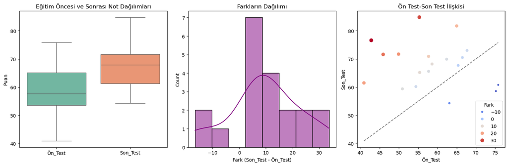

```python
# 2. Görselleştirme
plt.figure(figsize=(15, 5))

plt.subplot(1, 3, 1)
sns.boxplot(data=df[['Ön_Test', 'Son_Test']], palette="Set2")
plt.title('Eğitim Öncesi ve Sonrası Not Dağılımları')
plt.ylabel('Puan')

plt.subplot(1, 3, 2)
sns.histplot(df['Fark'], kde=True, color='purple', bins=8)
plt.title('Farkların Dağılımı')
plt.xlabel('Fark (Son_Test - Ön_Test)')

plt.subplot(1, 3, 3)
sns.scatterplot(x='Ön_Test', y='Son_Test', data=df, hue='Fark', palette='coolwarm', size='Fark')
plt.plot([df['Ön_Test'].min(), df['Ön_Test'].max()],
         [df['Ön_Test'].min(), df['Ön_Test'].max()], '--', color='gray')
plt.title('Ön Test-Son Test İlişkisi')

plt.tight_layout()
plt.show()
```

```python
# 3. Normallik Testi (Shapiro-Wilk)
print("\n📏 Normallik Testi Sonuçları:")
shapiro_stat, shapiro_p = stats.shapiro(df['Fark'])
print(f"Shapiro-Wilk Testi: W = {shapiro_stat:.3f}, p = {shapiro_p:.4f}")
if shapiro_p > 0.05:
    print("→ Farklar normal dağılıyor (p > 0.05)")
else:
    print("→ Farklar normal dağılmıyor (p ≤ 0.05)")
```

```
📏 Normallik Testi Sonuçları:
Shapiro-Wilk Testi: W = 0.955, p = 0.4501
→ Farklar normal dağılıyor (p > 0.05)
```

```python
# 4. Bağımlı İki Örneklem T Testi
print("\n🔍 Bağımlı İki Örneklem T Testi Sonuçları:")
t_stat, p_value = stats.ttest_rel(df['Son_Test'], df['Ön_Test'])

# Hipotezler
print("\nHipotezler:")
print("H₀: Eğitim programının sınav notları üzerinde etkisi yoktur (μd = 0)")
print("H₁: Eğitim programının sınav notları üzerinde etkisi vardır (μd ≠ 0)")

# Test sonuçları
print(f"\nt-istatistiği: {t_stat:.4f}")
print(f"p-değeri: {p_value:.4f}")

# Karar kuralı (α = 0.05)
alpha = 0.05
if p_value < alpha:
    print(f"\n✅ SONUÇ: p < {alpha} → H₀ REDDEDİLİR")
    print("Eğitim programının sınav notları üzerinde istatistiksel olarak anlamlı bir etkisi vardır.")
else:
    print(f"\n❌ SONUÇ: p ≥ {alpha} → H₀ REDDEDİLEMEZ")
    print("Eğitim programının sınav notları üzerinde istatistiksel olarak anlamlı bir etkisi yoktur.")
```

```
🔍 Bağımlı İki Örneklem T Testi Sonuçları:

Hipotezler:
H₀: Eğitim programının sınav notları üzerinde etkisi yoktur (μd = 0)
H₁: Eğitim programının sınav notları üzerinde etkisi vardır (μd ≠ 0)

t-istatistiği: 3.2343
p-değeri: 0.0044

✅ SONUÇ: p < 0.05 → H₀ REDDEDİLİR
Eğitim programının sınav notları üzerinde istatistiksel olarak anlamlı bir etkisi vardır.
```

```python
# 5. Ek Analizler
print("\n📈 Ek Analizler:")

# Güven aralığı
n = len(df)
dof = n - 1
ci = stats.t.interval(confidence=0.95, df=dof,
                     loc=df['Fark'].mean(),
                     scale=df['Fark'].std(ddof=1)/np.sqrt(n))
print(f"%95 Güven Aralığı: ({ci[0]:.2f}, {ci[1]:.2f})")

# Etki büyüklüğü (Cohen's d)
cohen_d = df['Fark'].mean() / df['Fark'].std(ddof=1)
print(f"Cohen's d (Etki Büyüklüğü): {cohen_d:.2f}")

# Etki yorumu
effect_size = ""
if abs(cohen_d) < 0.2:
    effect_size = "Çok küçük etki"
elif 0.2 <= abs(cohen_d) < 0.5:
    effect_size = "Küçük etki"
elif 0.5 <= abs(cohen_d) < 0.8:
    effect_size = "Orta etki"
else:
    effect_size = "Büyük etki"
print(f"→ Yorum: {effect_size}")



# Başarı oranı
improvement_rate = (df['Fark'] > 0).mean() * 100
print(f"\n📌 Katılımcıların %{improvement_rate:.1f}'si eğitim sonrasında daha yüksek puan almıştır.")


# Kendi veri setinizi Ön_Test ve Son_Test sütunlarına girerek doğrudan kullanabilirsiniz.
```

```
📈 Ek Analizler:
%95 Güven Aralığı: (3.38, 15.77)
Cohen's d (Etki Büyüklüğü): 0.72
→ Yorum: Orta etki

📌 Katılımcıların %85.0'si eğitim sonrasında daha yüksek puan almıştır.
```

3. **Diyetin Etkisi:**
- Problem: Bir diyet programının uygulanmasından önce ve sonra, bireylerin kilo kaybını değerlendirmek isteniyor.
- Ölçüm: Diyet öncesi ve diyet sonrası kilo ölçümleri.
- Hipotez: Diyet öncesi ve sonrasında kilo kaybında istatistiksel olarak anlamlı bir fark var mı?

```python
# Diyet Programının Kilo Kaybına Etkisi Analizi (Bağımlı Örneklem T-Testi)

import numpy as np
import pandas as pd
from scipy import stats
import matplotlib.pyplot as plt
import seaborn as sns

# 1. Veri Hazırlama
np.random.seed(45)  # Tekrarlanabilirlik için
katilimci_sayisi = 25

data = {
    'Katılımcı': [f'K{i+1}' for i in range(katilimci_sayisi)],
    'Diyet_Öncesi': np.random.normal(85, 10, katilimci_sayisi).round(1),
    'Diyet_Sonrası': np.random.normal(80, 9, katilimci_sayisi).round(1)  # Ortalama 5 kg azalma
}

df = pd.DataFrame(data)
df['Kilo_Farkı'] = df['Diyet_Öncesi'] - df['Diyet_Sonrası']
df['Yüzde_Değişim'] = (df['Kilo_Farkı'] / df['Diyet_Öncesi']) * 100
```

```python
# 2. Tanımlayıcı İstatistikler
print("="*55)
print("📉 DİYET PROGRAMI KİLO KAYBI ETKİ ANALİZİ")
print("="*55)

print("\n🔍 Temel İstatistikler:")
desc_stats = df[['Diyet_Öncesi', 'Diyet_Sonrası', 'Kilo_Farkı', 'Yüzde_Değişim']].describe().T
desc_stats['IQR'] = desc_stats['75%'] - desc_stats['25%']
print(desc_stats[['count', 'mean', 'std', 'min', '25%', '50%', '75%', 'max', 'IQR']])
```

```
=======================================================
📉 DİYET PROGRAMI KİLO KAYBI ETKİ ANALİZİ
=======================================================

🔍 Temel İstatistikler:
               count       mean        std        min        25%        50%  \
Diyet_Öncesi    25.0  79.960000   8.890210  59.000000  72.300000  81.000000
Diyet_Sonrası   25.0  79.380000   8.903557  65.100000  74.100000  77.300000
Kilo_Farkı      25.0   0.580000  10.138828 -17.200000  -6.700000   0.200000
Yüzde_Değişim   25.0  -0.089165  12.861001 -28.305085  -7.900943   0.253485

                     75%        max        IQR
Diyet_Öncesi   87.600000   94.40000  15.300000
Diyet_Sonrası  85.200000  100.20000  11.100000
Kilo_Farkı     10.600000   17.00000  17.300000
Yüzde_Değişim  12.059158   18.27957  19.960102
```

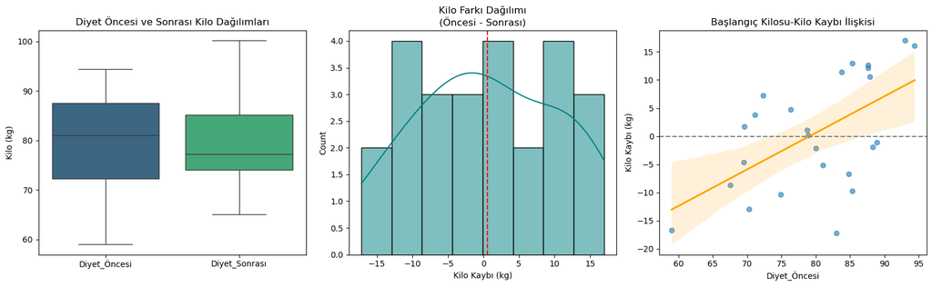

```python
# 3. Görselleştirme
plt.figure(figsize=(16, 5))

plt.subplot(1, 3, 1)
sns.boxplot(data=df[['Diyet_Öncesi', 'Diyet_Sonrası']], palette="viridis")
plt.title('Diyet Öncesi ve Sonrası Kilo Dağılımları')
plt.ylabel('Kilo (kg)')

plt.subplot(1, 3, 2)
sns.histplot(df['Kilo_Farkı'], kde=True, color='teal', bins=8)
plt.axvline(df['Kilo_Farkı'].mean(), color='red', linestyle='--')
plt.title('Kilo Farkı Dağılımı\n(Öncesi - Sonrası)')
plt.xlabel('Kilo Kaybı (kg)')

plt.subplot(1, 3, 3)
sns.regplot(x='Diyet_Öncesi', y='Kilo_Farkı', data=df,
            scatter_kws={'alpha':0.6}, line_kws={'color':'orange'})
plt.axhline(0, color='gray', linestyle='--')
plt.title('Başlangıç Kilosu-Kilo Kaybı İlişkisi')
plt.ylabel('Kilo Kaybı (kg)')

plt.tight_layout()
plt.show()
```

```python
# 4. Normallik Testi
print("\n📏 Normallik Testi Sonuçları:")
shapiro_stat, shapiro_p = stats.shapiro(df['Kilo_Farkı'])
print(f"Shapiro-Wilk Testi: W = {shapiro_stat:.3f}, p = {shapiro_p:.4f}")
if shapiro_p > 0.05:
    print("→ Kilo farkları normal dağılıyor (p > 0.05)")
else:
    print("→ Kilo farkları normal dağılmıyor (p ≤ 0.05)")
```

```
📏 Normallik Testi Sonuçları:
Shapiro-Wilk Testi: W = 0.963, p = 0.4666
→ Kilo farkları normal dağılıyor (p > 0.05)
```

```python
# 5. Bağımlı T-Testi
print("\n🔬 Bağımlı İki Örneklem T Testi Sonuçları:")

# Hipotezler
print("\nHipotezler:")
print("H₀: Diyet programının kilo kaybı üzerinde etkisi yoktur (μd = 0)")
print("H₁: Diyet programının kilo kaybı üzerinde etkisi vardır (μd > 0)")

# Tek yönlü test için
t_stat, p_value = stats.ttest_rel(df['Diyet_Öncesi'], df['Diyet_Sonrası'])
p_value_tek_yonlu = p_value / 2  # Tek kuyruklu test için

print(f"\nt-istatistiği: {t_stat:.4f}")
print(f"p-değeri (tek yönlü): {p_value_tek_yonlu:.6f}")

# Karar kuralı (α = 0.05)
alpha = 0.05
if p_value_tek_yonlu < alpha:
    print(f"\n✅ SONUÇ: p < {alpha} → H₀ REDDEDİLİR")
    print("Diyet programının kilo kaybı üzerinde istatistiksel olarak anlamlı bir etkisi vardır.")
else:
    print(f"\n❌ SONUÇ: p ≥ {alpha} → H₀ REDDEDİLEMEZ")
    print("Diyet programının kilo kaybı üzerinde istatistiksel olarak anlamlı bir etkisi yoktur.")
```

```
🔬 Bağımlı İki Örneklem T Testi Sonuçları:

Hipotezler:
H₀: Diyet programının kilo kaybı üzerinde etkisi yoktur (μd = 0)
H₁: Diyet programının kilo kaybı üzerinde etkisi vardır (μd > 0)

t-istatistiği: 0.2860
p-değeri (tek yönlü): 0.388655

❌ SONUÇ: p ≥ 0.05 → H₀ REDDEDİLEMEZ
Diyet programının kilo kaybı üzerinde istatistiksel olarak anlamlı bir etkisi yoktur.
```

```python
# 6. Kapsamlı Ek Analizler - Bonus Kod
print("\n📊 Detaylı Analizler:")

# Güven aralığı
n = len(df)
dof = n - 1
ci = stats.t.interval(confidence=0.95, df=dof,
                     loc=df['Kilo_Farkı'].mean(),
                     scale=df['Kilo_Farkı'].std(ddof=1)/np.sqrt(n))
print(f"Ortalama kilo kaybı için %95 Güven Aralığı: ({ci[0]:.2f} kg, {ci[1]:.2f} kg)")

# Etki büyüklüğü (Cohen's d)
cohen_d = df['Kilo_Farkı'].mean() / df['Kilo_Farkı'].std(ddof=1)
print(f"\nCohen's d (Etki Büyüklüğü): {cohen_d:.2f}")

# Etki yorumu
if cohen_d < 0.2:
    etki_boyutu = "Çok küçük etki"
elif 0.2 <= cohen_d < 0.5:
    etki_boyutu = "Küçük etki"
elif 0.5 <= cohen_d < 0.8:
    etki_boyutu = "Orta etki"
else:
    etki_boyutu = "Büyük etki"
print(f"→ Yorum: {etki_boyutu}")

# Başarı oranı
basarili_olanlar = (df['Kilo_Farkı'] > 0).sum()
basarili_oran = (basarili_olanlar / n) * 100
print(f"\n💪 Katılımcıların %{basarili_oran:.1f}'si ({basarili_olanlar}/{n}) kilo vermiştir")

# Kilo verenlerin ortalama kaybı
if basarili_olanlar > 0:
    ortalama_kayip = df[df['Kilo_Farkı'] > 0]['Kilo_Farkı'].mean()
    print(f"→ Kilo verenlerin ortalama kaybı: {ortalama_kayip:.1f} kg")

# Korelasyon analizi
corr, p_corr = stats.pearsonr(df['Diyet_Öncesi'], df['Kilo_Farkı'])
print(f"\n📈 Başlangıç kilosu ile kilo kaybı arası korelasyon: r = {corr:.2f} (p = {p_corr:.4f})")
if p_corr < 0.05:
    if corr > 0:
        print("→ Daha yüksek başlangıç kilosu olanlar daha fazla kilo vermiştir")
    else:
        print("→ Daha yüksek başlangıç kilosu olanlar daha az kilo vermiştir")
else:
    print("→ Başlangıç kilosu ile kilo kaybı arasında anlamlı ilişki yok")
```

```
📊 Detaylı Analizler:
Ortalama kilo kaybı için %95 Güven Aralığı: (-3.61 kg, 4.77 kg)

Cohen's d (Etki Büyüklüğü): 0.06
→ Yorum: Çok küçük etki

💪 Katılımcıların %52.0'si (13/25) kilo vermiştir
→ Kilo verenlerin ortalama kaybı: 8.6 kg

📈 Başlangıç kilosu ile kilo kaybı arası korelasyon: r = 0.57 (p = 0.0030)
→ Daha yüksek başlangıç kilosu olanlar daha fazla kilo vermiştir
```

4. **Eğitim Yöntemi Karşılaştırması:**
- Problem: İki farklı eğitim yöntemi uygulandıktan sonra, katılımcıların belirli bir becerideki değişikliği değerlendirmek isteniyor.
- Ölçüm: İlk eğitim yöntemi ve ikinci eğitim yöntemi öncesi ve sonrası performans puanları.
- Hipotez: İki eğitim yöntemi arasında beceride istatistiksel olarak anlamlı bir fark var mı?

```python
# Eğitim Yöntemlerinin Karşılaştırılması için Bağımlı ve Bağımsız Örneklem Analizi

import numpy as np
import pandas as pd
from scipy import stats
import matplotlib.pyplot as plt
import seaborn as sns
from statsmodels.stats.power import TTestIndPower

# 1. Veri Oluşturma ve Hazırlık
np.random.seed(51)
katilimci_sayisi = 30  # Her grup için

# Grup 1 (Geleneksel Yöntem)
grup1_on = np.random.normal(65, 8, katilimci_sayisi).round(1)
grup1_son = np.random.normal(72, 7, katilimci_sayisi).round(1)

# Grup 2 (Yeni Yöntem)
grup2_on = np.random.normal(64, 9, katilimci_sayisi).round(1)
grup2_son = np.random.normal(78, 6, katilimci_sayisi).round(1)

# DataFrame oluşturma
df = pd.DataFrame({
    'Grup': ['Geleneksel']*katilimci_sayisi + ['Yeni']*katilimci_sayisi,
    'Katılımcı': [f'K{i+1}' for i in range(katilimci_sayisi)]*2,
    'Ön_Test': np.concatenate([grup1_on, grup2_on]),
    'Son_Test': np.concatenate([grup1_son, grup2_son])
})

# Farkları hesaplama
df['Fark'] = df['Son_Test'] - df['Ön_Test']
df['Yüzde_Artış'] = (df['Fark'] / df['Ön_Test']) * 100
```

```python
# 2. Tanımlayıcı İstatistikler
print("="*60)
print("📚 EĞİTİM YÖNTEMLERİ KARŞILAŞTIRMA ANALİZİ")
print("="*60)

print("\n📊 Gruplara Göre Temel İstatistikler:")
group_stats = df.groupby('Grup')[['Ön_Test', 'Son_Test', 'Fark', 'Yüzde_Artış']].agg(['mean', 'std', 'count'])
print(group_stats.round(2))
```

```
============================================================
📚 EĞİTİM YÖNTEMLERİ KARŞILAŞTIRMA ANALİZİ
============================================================

📊 Gruplara Göre Temel İstatistikler:
           Ön_Test              Son_Test               Fark               \
              mean    std count     mean   std count   mean    std count
Grup
Geleneksel   65.13   8.14    30    71.58  5.08    30   6.45   9.45    30
Yeni         63.92  11.27    30    76.50  6.25    30  12.59  12.55    30

           Yüzde_Artış
                  mean    std count
Grup
Geleneksel       11.46  15.35    30
Yeni             24.23  29.84    30
```

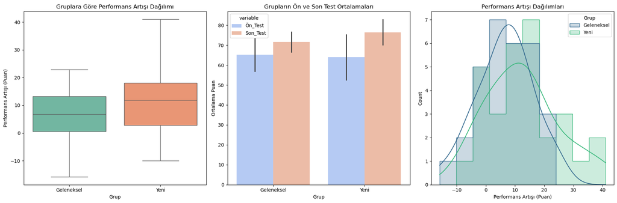

```python
# 3. Görselleştirme
plt.figure(figsize=(18, 6))

# Kutu grafikleri
plt.subplot(1, 3, 1)
sns.boxplot(x='Grup', y='Fark', data=df, palette="Set2")
plt.title('Gruplara Göre Performans Artışı Dağılımı')
plt.ylabel('Performans Artışı (Puan)')

# Ön-Son Test Karşılaştırması
plt.subplot(1, 3, 2)
sns.barplot(x='Grup', y='value', hue='variable',
            data=pd.melt(df, id_vars=['Grup'], value_vars=['Ön_Test', 'Son_Test']),
            palette="coolwarm", ci='sd')
plt.title('Grupların Ön ve Son Test Ortalamaları')
plt.ylabel('Ortalama Puan')

# Performans Artışı Dağılımı
plt.subplot(1, 3, 3)
sns.histplot(data=df, x='Fark', hue='Grup', kde=True,
             palette="viridis", bins=10, element="step")
plt.title('Performans Artışı Dağılımları')
plt.xlabel('Performans Artışı (Puan)')

plt.tight_layout()
plt.show()
```

```python
# 4. Normallik Testleri
print("\n📏 Normallik Testleri (Shapiro-Wilk):")
for grup in df['Grup'].unique():
    stat, p = stats.shapiro(df[df['Grup']==grup]['Fark'])
    print(f"{grup} Yöntemi Farkları: W = {stat:.3f}, p = {p:.4f}")
```

```
📏 Normallik Testleri (Shapiro-Wilk):
Geleneksel Yöntemi Farkları: W = 0.977, p = 0.7275
Yeni Yöntemi Farkları: W = 0.967, p = 0.4517
```

```python
# 5. Varyans Homojenliği Testi (Levene)
print("\n🔍 Varyans Homojenliği Testi (Levene):")
lev_stat, lev_p = stats.levene(df[df['Grup']=='Geleneksel']['Fark'],
                             df[df['Grup']=='Yeni']['Fark'])
print(f"Levene Testi: F = {lev_stat:.3f}, p = {lev_p:.4f}")
```

```
🔍 Varyans Homojenliği Testi (Levene):
Levene Testi: F = 1.896, p = 0.1738
```

```python
# 6. Bağımsız İki Örneklem T Testi (Yöntemler Arası Karşılaştırma)
print("\n🔬 Bağımsız İki Örneklem T Testi Sonuçları:")

# Hipotezler
print("\nHipotezler:")
print("H₀: İki eğitim yöntemi arasında performans artışı farkı yoktur (μ1 = μ2)")
print("H₁: İki eğitim yöntemi arasında performans artışı farkı vardır (μ1 ≠ μ2)")

# Test (varyansların homojenliğine göre)
if lev_p > 0.05:
    t_stat, p_value = stats.ttest_ind(df[df['Grup']=='Geleneksel']['Fark'],
                                    df[df['Grup']=='Yeni']['Fark'],
                                    equal_var=True)
    print("\nVaryanslar homojen (p > 0.05) - Eşit varyanslı t-testi kullanıldı")
else:
    t_stat, p_value = stats.ttest_ind(df[df['Grup']=='Geleneksel']['Fark'],
                                    df[df['Grup']=='Yeni']['Fark'],
                                    equal_var=False)
    print("\nVaryanslar homojen değil (p ≤ 0.05) - Welch'in t-testi kullanıldı")

print(f"\nt-istatistiği: {t_stat:.4f}")
print(f"p-değeri: {p_value:.4f}")

# Karar kuralı (α = 0.05)
alpha = 0.05
if p_value < alpha:
    print(f"\n✅ SONUÇ: p < {alpha} → H₀ REDDEDİLİR")
    print("İki eğitim yöntemi arasında istatistiksel olarak anlamlı bir fark vardır.")

    # Hangi yöntem daha iyi?
    if df[df['Grup']=='Geleneksel']['Fark'].mean() > df[df['Grup']=='Yeni']['Fark'].mean():
        print("→ Geleneksel yöntem daha fazla performans artışı sağlamıştır")
    else:
        print("→ Yeni yöntem daha fazla performans artışı sağlamıştır")
else:
    print(f"\n❌ SONUÇ: p ≥ {alpha} → H₀ REDDEDİLEMEZ")
    print("İki eğitim yöntemi arasında istatistiksel olarak anlamlı bir fark yoktur.")
```

```
🔬 Bağımsız İki Örneklem T Testi Sonuçları:

Hipotezler:
H₀: İki eğitim yöntemi arasında performans artışı farkı yoktur (μ1 = μ2)
H₁: İki eğitim yöntemi arasında performans artışı farkı vardır (μ1 ≠ μ2)

Varyanslar homojen (p > 0.05) - Eşit varyanslı t-testi kullanıldı

t-istatistiği: -2.1391
p-değeri: 0.0367

✅ SONUÇ: p < 0.05 → H₀ REDDEDİLİR
İki eğitim yöntemi arasında istatistiksel olarak anlamlı bir fark vardır.
→ Yeni yöntem daha fazla performans artışı sağlamıştır
```

```python
# 7. Kapsamlı Ek Analizler
print("\n📈 Detaylı Analizler:")

# Etki büyüklüğü (Cohen's d)
def cohens_d(group1, group2):
    diff = group1.mean() - group2.mean()
    n1, n2 = len(group1), len(group2)
    var1, var2 = group1.var(ddof=1), group2.var(ddof=1)
    pooled_std = np.sqrt(((n1-1)*var1 + (n2-1)*var2) / (n1+n2-2))
    return diff / pooled_std

d = cohens_d(df[df['Grup']=='Yeni']['Fark'],
             df[df['Grup']=='Geleneksel']['Fark'])
print(f"\nCohen's d (Etki Büyüklüğü): {abs(d):.2f}")

# Etki yorumu
if abs(d) < 0.2:
    etki_boyutu = "Çok küçük etki"
elif 0.2 <= abs(d) < 0.5:
    etki_boyutu = "Küçük etki"
elif 0.5 <= abs(d) < 0.8:
    etki_boyutu = "Orta etki"
else:
    etki_boyutu = "Büyük etki"
print(f"→ Yorum: {etki_boyutu}")

# Güç analizi
effect_size = abs(d)
alpha = 0.05
power = 0.8
analysis = TTestIndPower()
required_n = analysis.solve_power(effect_size=effect_size, alpha=alpha, power=power)
print(f"\n⏳ Güç analizi (0.8 güç, α=0.05 için):")
print(f"→ Tespit edilebilir minimum etki büyüklüğü: {effect_size:.2f}")
print(f"→ Önerilen minimum örneklem büyüklüğü (grup başına): {int(np.ceil(required_n))}")

# Grup içi değişimler (paired t-test)
print("\n🔎 Grup İçi Değişim Analizleri:")
for grup in df['Grup'].unique():
    t_stat, p_value = stats.ttest_rel(df[df['Grup']==grup]['Son_Test'],
                                      df[df['Grup']==grup]['Ön_Test'])
    print(f"\n{grup} Yöntemi:")
    print(f"→ Ön Test Ort: {df[df['Grup']==grup]['Ön_Test'].mean():.1f}")
    print(f"→ Son Test Ort: {df[df['Grup']==grup]['Son_Test'].mean():.1f}")
    print(f"→ t({len(df[df['Grup']==grup])-1}) = {t_stat:.2f}, p = {p_value:.4f}")
    if p_value < 0.05:
        print("  → İstatistiksel olarak anlamlı gelişme (p < 0.05)")
    else:
        print("  → İstatistiksel olarak anlamlı gelişme yok")
```

```
📈 Detaylı Analizler:

Cohen's d (Etki Büyüklüğü): 0.55
→ Yorum: Orta etki

⏳ Güç analizi (0.8 güç, α=0.05 için):
→ Tespit edilebilir minimum etki büyüklüğü: 0.55
→ Önerilen minimum örneklem büyüklüğü (grup başına): 53

🔎 Grup İçi Değişim Analizleri:

Geleneksel Yöntemi:
→ Ön Test Ort: 65.1
→ Son Test Ort: 71.6
→ t(29) = 3.74, p = 0.0008
  → İstatistiksel olarak anlamlı gelişme (p < 0.05)

Yeni Yöntemi:
→ Ön Test Ort: 63.9
→ Son Test Ort: 76.5
→ t(29) = 5.50, p = 0.0000
  → İstatistiksel olarak anlamlı gelişme (p < 0.05)
```

5. **Yazılım Güncellemesi Etkisi:**
- Problem: Bir yazılım güncellemesi yapıldıktan sonra, kullanıcıların belirli bir işlem süresindeki değişimi değerlendirmek isteniyor.
- Ölçüm: Yazılım öncesi ve yazılım sonrası işlem süreleri.
- Hipotez: Yazılım güncellemesi öncesi ve sonrasında işlem sürelerinde istatistiksel olarak anlamlı bir fark var mı?

```python
# Yazılım Güncellemesinin Performans Etkisi Analizi# - Test: İki bağımlı örneklem t-testi (Paired Sample T-Test)

import numpy as np
import pandas as pd
from scipy import stats
import matplotlib.pyplot as plt
import seaborn as sns
from statsmodels.stats.power import TTestPower

# 1. Veri Hazırlama ve Ön İşleme
np.random.seed(42)
kullanici_sayisi = 50

# Gerçekçi veri simülasyonu (güncelleme sonrası iyileşme olduğunu varsayalım)
oncesi = np.random.exponential(scale=2.5, size=kullanici_sayisi).round(2)
sonrasi = np.random.exponential(scale=2.0, size=kullanici_sayisi).round(2)

# Aykırı değerleri kırpma (realist veri için)
oncesi = np.clip(oncesi, 0.5, 8.0)
sonrasi = np.clip(sonrasi, 0.4, 6.5)

df = pd.DataFrame({
    'Kullanıcı_ID': [f'K{i+1:03d}' for i in range(kullanici_sayisi)],
    'Güncelleme_Öncesi': oncesi,
    'Güncelleme_Sonrası': sonrasi
})

# Performans farkını hesaplama
df['Süre_Farkı'] = df['Güncelleme_Öncesi'] - df['Güncelleme_Sonrası']
df['Yüzde_İyileşme'] = (df['Süre_Farkı'] / df['Güncelleme_Öncesi']) * 100
```

```python
# 2. Tanımlayıcı İstatistikler
print("="*65)
print("🖥️ YAZILIM GÜNCELLEMESİ PERFORMANS ANALİZİ")
print("="*65)

print("\n📊 Temel Performans İstatistikleri:")
desc_stats = df[['Güncelleme_Öncesi', 'Güncelleme_Sonrası', 'Süre_Farkı', 'Yüzde_İyileşme']].describe().T
desc_stats['IQR'] = desc_stats['75%'] - desc_stats['25%']
print(desc_stats[['count', 'mean', 'std', 'min', '25%', '50%', '75%', 'max', 'IQR']].round(2))
```

```
=================================================================
🖥️ YAZILIM GÜNCELLEMESİ PERFORMANS ANALİZİ
=================================================================

📊 Temel Performans İstatistikleri:
                    count   mean     std     min    25%   50%    75%    max  \
Güncelleme_Öncesi    50.0   2.14    2.12    0.50   0.51  1.43   2.63   8.00
Güncelleme_Sonrası   50.0   1.97    1.68    0.40   0.49  1.42   2.95   6.50
Süre_Farkı           50.0   0.18    2.79   -5.64  -1.47 -0.05   1.32   7.37
Yüzde_İyileşme       50.0 -81.55  209.77 -920.00 -97.03 -6.59  59.21  94.62

                       IQR
Güncelleme_Öncesi     2.12
Güncelleme_Sonrası    2.46
Süre_Farkı            2.79
Yüzde_İyileşme      156.24
```

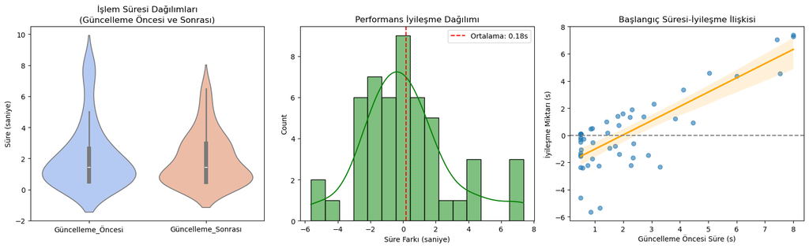

```python
# 3. Veri Görselleştirme
plt.figure(figsize=(16, 5))

# Süre Dağılımları
plt.subplot(1, 3, 1)
sns.violinplot(data=df[['Güncelleme_Öncesi', 'Güncelleme_Sonrası']], palette="coolwarm")
plt.title('İşlem Süresi Dağılımları\n(Güncelleme Öncesi ve Sonrası)')
plt.ylabel('Süre (saniye)')

# Performans İyileşmesi
plt.subplot(1, 3, 2)
sns.histplot(df['Süre_Farkı'], kde=True, color='green', bins=15)
plt.axvline(df['Süre_Farkı'].mean(), color='red', linestyle='--', label=f'Ortalama: {df["Süre_Farkı"].mean():.2f}s')
plt.title('Performans İyileşme Dağılımı')
plt.xlabel('Süre Farkı (saniye)')
plt.legend()

# Korelasyon Analizi
plt.subplot(1, 3, 3)
sns.regplot(x='Güncelleme_Öncesi', y='Süre_Farkı', data=df,
            scatter_kws={'alpha':0.6}, line_kws={'color':'orange'})
plt.axhline(0, color='gray', linestyle='--')
plt.title('Başlangıç Süresi-İyileşme İlişkisi')
plt.xlabel('Güncelleme Öncesi Süre (s)')
plt.ylabel('İyileşme Miktarı (s)')

plt.tight_layout()
plt.show()
```

```python
# 4. Normallik Testi
print("\n📏 Normallik Testi Sonuçları (Shapiro-Wilk):")
shapiro_stat, shapiro_p = stats.shapiro(df['Süre_Farkı'])
print(f"Farklar için: W = {shapiro_stat:.3f}, p = {shapiro_p:.4f}")
if shapiro_p > 0.05:
    print("→ Farklar normal dağılıyor (p > 0.05)")
else:
    print("→ Farklar normal dağılmıyor (p ≤ 0.05)")
```

```
📏 Normallik Testi Sonuçları (Shapiro-Wilk):
Farklar için: W = 0.932, p = 0.0064
→ Farklar normal dağılmıyor (p ≤ 0.05)
```

```python
# 5. Bağımlı T-Testi (Paired Samples)
print("\n🔍 Bağımlı İki Örneklem T Testi Sonuçları:")

# Hipotezler
print("\nHipotezler:")
print("H₀: Güncelleme öncesi ve sonrası işlem süreleri arasında fark yoktur (μd = 0)")
print("H₁: Güncelleme sonrası işlem süreleri daha kısadır (μd > 0)")

# Tek yönlü test için
t_stat, p_value = stats.ttest_rel(df['Güncelleme_Öncesi'], df['Güncelleme_Sonrası'])
p_value_tek_yonlu = p_value / 2

print(f"\nt-istatistiği: {t_stat:.4f}")
print(f"p-değeri (tek yönlü): {p_value_tek_yonlu:.6f}")

# Karar kuralı (α = 0.05)
alpha = 0.05
if p_value_tek_yonlu < alpha:
    print(f"\n✅ SONUÇ: p < {alpha} → H₀ REDDEDİLİR")
    print("Yazılım güncellemesi işlem sürelerinde istatistiksel olarak anlamlı bir iyileşme sağlamıştır.")
else:
    print(f"\n❌ SONUÇ: p ≥ {alpha} → H₀ REDDEDİLEMEZ")
    print("Yazılım güncellemesinin işlem süreleri üzerinde istatistiksel olarak anlamlı bir etkisi yoktur.")
```

```
🔍 Bağımlı İki Örneklem T Testi Sonuçları:

Hipotezler:
H₀: Güncelleme öncesi ve sonrası işlem süreleri arasında fark yoktur (μd = 0)
H₁: Güncelleme sonrası işlem süreleri daha kısadır (μd > 0)

t-istatistiği: 0.4542
p-değeri (tek yönlü): 0.325857

❌ SONUÇ: p ≥ 0.05 → H₀ REDDEDİLEMEZ
Yazılım güncellemesinin işlem süreleri üzerinde istatistiksel olarak anlamlı bir etkisi yoktur.
```

```python
# 6. Kapsamlı Ek Analizler
print("\n📈 Detaylı Performans Analizleri:")

# Güven aralığı
n = len(df)
dof = n - 1
ci = stats.t.interval(confidence=0.95, df=dof,
                     loc=df['Süre_Farkı'].mean(),
                     scale=df['Süre_Farkı'].std(ddof=1)/np.sqrt(n))
print(f"\nOrtalama iyileşme için %95 Güven Aralığı: ({ci[0]:.3f}s, {ci[1]:.3f}s)")

# Etki büyüklüğü (Cohen's d)
cohen_d = df['Süre_Farkı'].mean() / df['Süre_Farkı'].std(ddof=1)
print(f"Cohen's d (Etki Büyüklüğü): {cohen_d:.3f}")

# Etki yorumu
if cohen_d < 0.2:
    etki_boyutu = "Çok küçük etki"
elif 0.2 <= cohen_d < 0.5:
    etki_boyutu = "Küçük etki"
elif 0.5 <= cohen_d < 0.8:
    etki_boyutu = "Orta etki"
else:
    etki_boyutu = "Büyük etki"
print(f"→ Yorum: {etki_boyutu}")

# İyileşen kullanıcı oranı
iyilesen = (df['Süre_Farkı'] > 0).sum()
iyilesme_orani = (iyilesen / n) * 100
print(f"\n👥 Kullanıcıların %{iyilesme_orani:.1f}'si ({iyilesen}/{n}) güncelleme sonrasında daha hızlı işlem deneyimi yaşamıştır")

# Güç analizi
effect_size = cohen_d
power_analysis = TTestPower()
power = power_analysis.solve_power(effect_size=effect_size, nobs=n, alpha=alpha)
print(f"\n📊 Güç Analizi (Mevcut çalışma için):")
print(f"→ Tespit edilen etki büyüklüğü: {effect_size:.3f}")
print(f"→ Çalışmanın istatistiksel gücü: {power:.3f}")

# Süre iyileşmesi ile başlangıç süresi korelasyonu
corr, p_corr = stats.pearsonr(df['Güncelleme_Öncesi'], df['Süre_Farkı'])
print(f"\n📉 Başlangıç Süresi-İyileşme Korelasyonu: r = {corr:.3f}, p = {p_corr:.4f}")
if p_corr < 0.05:
    if corr > 0:
        print("→ Daha yavaş sistemlerde daha fazla iyileşme gözlenmiştir")
    else:
        print("→ Daha hızlı sistemlerde daha fazla iyileşme gözlenmiştir")
else:
    print("→ Başlangıç süresi ile iyileşme miktarı arasında anlamlı ilişki yok")
```

```
📈 Detaylı Performans Analizleri:

Ortalama iyileşme için %95 Güven Aralığı: (-0.613s, 0.971s)
Cohen's d (Etki Büyüklüğü): 0.064
→ Yorum: Çok küçük etki

👥 Kullanıcıların %50.0'si (25/50) güncelleme sonrasında daha hızlı işlem deneyimi yaşamıştır

📊 Güç Analizi (Mevcut çalışma için):
→ Tespit edilen etki büyüklüğü: 0.064
→ Çalışmanın istatistiksel gücü: 0.073

📉 Başlangıç Süresi-İyileşme Korelasyonu: r = 0.798, p = 0.0000
→ Daha yavaş sistemlerde daha fazla iyileşme gözlenmiştir
```

## İş Uygulaması : Şirket içi Eğitimin Performans Etkisi Ölçümü

Satış Departmanı satış elemanlarının performanslarını artıracak bir eğitim talep ediyor.  
Eğitim öncesinde ilgili kişilerin satş performansları belirli metriklere göre ölçülüyor. ex. ortalama satış, birim satış, günlük satış olabilir. Sonrasında bir eğitim programı düzenleniyor ve bu eğitimin ne kadar işe yarayıp yaramadığını ölçmek üzere bir test işlemi gerçekleştirilmek isteniyor.

Problem:

Belirli uğraşlar sonucnda alınan bir eğitimin katma değer sağlayıp sağlamadığı ölçülmek isteniyor.

Detaylar:

Bir departman bir konuda eğitim taelp ediyor.

Gerekli/gereksizdeğerlendirmeleri neticesinde eğitim alınıyor.

Eğitimden önce ve sonra olacak şekilde gerekli ölçümler yapılıyor.

Eğitim sonrasında eğitimin sağladığı katma değer test edilmek isteniyor.

HİPOTEZ:

H0 : Eğitimin öncesinde katılımcılarınilgili konudaki performnas ortalamaları ileeğitim sonra performanslarına ilişkin ortalamalarbirbirinden farklı değildir.

H1 : Eğitim etkili olmuştur. Bir farklılık oluşturmuştur.

```python
import numpy as np
import pandas as pd
import seaborn as sns
import matplotlib.pyplot as plt

#veriyi excel , csv veya veritababından okuduğumuzu varsayalım, Bu örnekte, `öncesi` ve `sonrasi` adlı iki örneklem arasında bağımlı iki örneklem t-testi gerçekleştirilmiştir.

#Eğitimden önce ve sonrasında elemanların performans ölçümlerine ait değerler
oncesi=pd.DataFrame([123,119,119,116,123,123,121,120,117,118,121,121,123,119,121,118,124,121,125,115,115,119,118,121,117,117,120,120,121,117,118,117,123,118,124,121,115,118,125,115])
sonrasi=pd.DataFrame([118,127,122,132,129,123,129,132,128,130,128,138,140,130,134,134,124,140,134,129,129,138,134,124,122,126,133,127,130,130,130,132,117,130,125,129,133,120,127,123])
```

```python
oncesi[0:5] #ilk 5 elemanı gösterelim
```

|  | 0 |
| --- | --- |
| 0 | 123 |
| 1 | 119 |
| 2 | 119 |
| 3 | 116 |
| 4 | 123 |

```python
sonrasi[0:5] #ilk 5 elemanı gösterelim
```

|  | 0 |
| --- | --- |
| 0 | 118 |
| 1 | 127 |
| 2 | 122 |
| 3 | 132 |
| 4 | 129 |

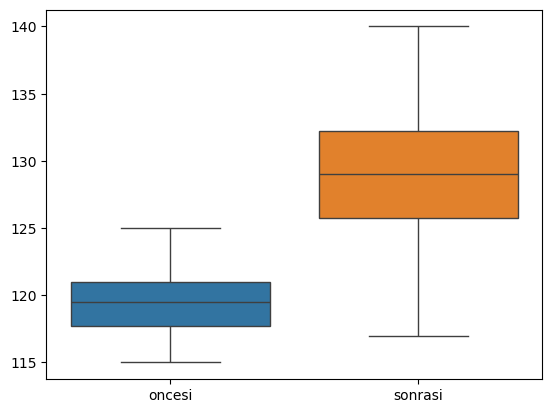

```python
before_after = pd.concat([oncesi,sonrasi],axis=1)
before_after.columns = ['oncesi','sonrasi']
before_after[:5]
# `before_after` veri çerçevesi, `öncesi` ve `sonrasi` adlı iki sütundan oluşmaktadır. Bu sütunlar, eğitim öncesi ve sonrası performans ölçümlerini içermektedir.
sns.boxplot(before_after)
```

```python
#BIRINCI VERI SETI

AYRIK = pd.concat([oncesi, sonrasi], axis = 1)
AYRIK.columns = ["ONCESI","SONRASI"]
print("'AYRIK' Veri Seti: \n\n", AYRIK.head(), "\n\n")
```

```
'AYRIK' Veri Seti:

    ONCESI  SONRASI
0     123      118
1     119      127
2     119      122
3     116      132
4     123      129
```

```python
#IKINCI VERI SETI
#ONCESİ FALG/TAG'INI OLUŞTURMA

GRUP_ONCESI = np.arange(len(oncesi))  #ONCESI veri setindeki gözlem sayısı kadar bir np dizi oluşturuyoruz
GRUP_ONCESI = pd.DataFrame(GRUP_ONCESI) #oluşan diziyi pandas dataframe'e çeviriyoruz
GRUP_ONCESI[:] = "ONCESI"  #tüm değerleri "ONCESI" olarak değiştiriyoruz

#FLAG VE ONCESI DEĞERLERİNİ BİR ARAYA GETIRME
A = pd.concat([oncesi, GRUP_ONCESI], axis = 1)

#SONRASI FLAG/TAG'INI OLUŞTURMA
GRUP_SONRASI = np.arange(len(sonrasi))
GRUP_SONRASI = pd.DataFrame(GRUP_SONRASI)
GRUP_SONRASI[:] = "SONRASI"


#FLAG VE SONRASI DEĞERLERİNİ BİR ARAYA GETIRME
B = pd.concat([sonrasi, GRUP_SONRASI], axis = 1)

#TUM VERIYI BIR ARAYA GETIRME
BIRLIKTE = pd.concat([A,B])  #A ve B veri setlerini birleştiriyoruz
print(BIRLIKTE)
```

```
      0        0
0   123   ONCESI
1   119   ONCESI
2   119   ONCESI
3   116   ONCESI
4   123   ONCESI
..  ...      ...
35  129  SONRASI
36  133  SONRASI
37  120  SONRASI
38  127  SONRASI
39  123  SONRASI

[80 rows x 2 columns]
```

```python
#ISIMLENDIRME
BIRLIKTE.columns = ["PERFORMANS","ONCESI_SONRASI"]
print("'BIRLIKTE' Veri Seti: \n\n", BIRLIKTE.head(), "\n\n")
```

```
'BIRLIKTE' Veri Seti:

    PERFORMANS ONCESI_SONRASI
0         123         ONCESI
1         119         ONCESI
2         119         ONCESI
3         116         ONCESI
4         123         ONCESI
```

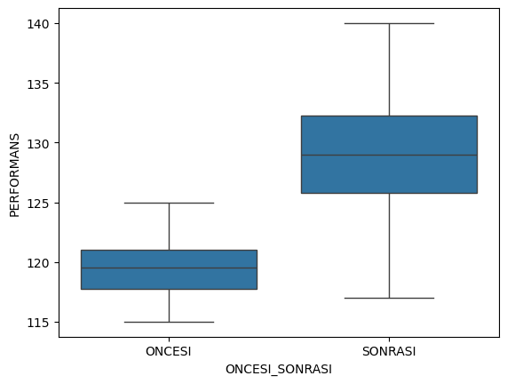

```python
sns.boxplot(x = "ONCESI_SONRASI", y = "PERFORMANS", data = BIRLIKTE)
```

Aslında grafikten bariz bir şekilde eğitimlerin işe yaradığını görüyoruz ama yinede bilimsel olarak test yapmamız gerekiyor.

İlk önce Varsayım Kontrollerini gerçekleştiriyoruz:

### BAĞIMLI İKİ ÖRNEKLEM T TESTİ VARSAYIM KONTROLLERİ

Bilimsel bir referans noktası, bilimsel bir karşılaştırma noktasını alıp işlemi güvenli bir şekilde yapmak için gerekli varsayımların sağlanması gerekiyor.

```python
#normallik varsayımını kontrol edelim
from scipy.stats import shapiro #normal dağılımı inceler
# p-value>0.05 H0 hipotezini reddemeyiz 'HO:dağılım normaldir'
# p-value<0.05 H0 hipotezini reddeder 'HO:dağılım normal değildir'
```

```python
shapiro(AYRIK.ONCESI) #shapiro testi uyguluyoruz, bu fonsiyonun içerisine testini yapmak istediğimiz değişkeni giriyoruz. sol taraftaki değer test istatistiğini, sağ taraftaki değer ise p-value değerini verir
```

```
ShapiroResult(statistic=0.9543651286601341, pvalue=0.10722012473424775)
```

```python
shapiro(AYRIK.SONRASI) #shapiro testi uyguluyoruz, bu fonsiyonun içerisine testini yapmak istediğimiz değişkeni giriyoruz. sol taraftaki değer test istatistiğini, sağ taraftaki değer ise p-value değerini verir
```

```
ShapiroResult(statistic=0.9780089132335147, pvalue=0.6159508885102487)
```

> iki veri setinde de dağılımın normal olduğunu görüyoruz. ikisinde de pvalue>0.05

Teorik dağılım ve örnek dağılımın arasında bir fark yoktur.

```python
#varyans homojenliği varsayımı için levene testi uygulayalım

from scipy.stats import levene #varyans homojenliği varsayımını inceler

# p-value>0.05 H0 hipotezini kabul  eder 'HO:Varyanslar homojendir'
# p-value<0.05 H0 hipotezini reddeder 'HO:Varyanslar homojen değildir'

levene(AYRIK.ONCESI, AYRIK.SONRASI) #levene testi uyguluyoruz, bu fonsiyonun içerisine testini yapmak istediğimiz iki değişkeni giriyoruz. sol taraftaki değer test istatistiğini, sağ taraftaki değer ise p-value değerini verir
```

```
LeveneResult(statistic=8.31303288672351, pvalue=0.0050844511807370246)
```

> Bu durumda H0 hipotezini red etmek durumundayız çünkü p-value < 0.05

İkinci varsayımımız olan varyansların homojenliği sağlanmamaktadır.

Bazı durumlarda varyansların homojenliği göz ardı edilebilir. Biz şimdi bu durum sağlanmışcasına yada bu varsayımı göz ardı ediyormuşcasına devam edeceğiz ve ilgili testimizi gerçekleştireceğiz.

## ==Hipotez Testi==

```python
from scipy.stats import ttest_rel #bağımlı iki örneklem t testi uygulamak için gerekli modülü import edelim
```

```python
ttest_rel(AYRIK.ONCESI, AYRIK.SONRASI) #bağımlı iki örneklem t testi uyguluyoruz, bu fonsiyonun içerisine testini yapmak istediğimiz iki değişkeni giriyoruz. sol taraftaki değer test istatistiğini, sağ taraftaki değer ise p-value değerini verir
```

```
TtestResult(statistic=-9.281533480429937, pvalue=2.0235251764440722e-11, df=39)
```

```python
test_istatistiği,pvalue= ttest_rel(AYRIK.ONCESI, AYRIK.SONRASI) # test istatistiği ve p-value değerlerini test_istatistiği ve pvalue değişkenlerine atıyoruz
print('test_istatistiği : %.4f \npvalue:  %.15f ' %(test_istatistiği,pvalue))
```

```
test_istatistiği : -9.2815
pvalue:  0.000000000020235
```

Hipotezimizin Yorumu:

HO ne diyordu: Çalışanlarımıza eğitim vermeden önceki performanslarıyla eğitim verdikten sonrası performansları karşılaştırıldığında, bu performansların ortalamaları arasında istatistiki oılarak anlamlı bir farklılık yoktur.

P-value değeri incelendiğinde; H0 hipotezi reddedilir, yani eğitim işe yaramıştır.

Bu testin sonucunda elde edilen p değeri, null hipotezin reddedilip edilemeyeceğini belirler. Düşük bir p değeri (genellikle 0.05'ten küçük) null hipotezin reddedilmesi için yeterli kanıt olarak kabul edilir, bu da iki koşul arasında bir fark olduğunu gösterir.

Güvenli bir şekilde performanslarını artırabildiğimizi kabul edebiliriz.

## **Non Parametrik Bağımlı İki Örneklem T-testi**

Nonparametrik bağımlı iki örneklem testi, aynı birey veya öğe üzerinde iki farklı koşul arasındaki farklılıkları değerlendirmek için kullanılır. Bu tür bir test, verilerin normal dağılıma uymadığı veya normal dağılım varsayımlarının sağlanamadığı durumlarda tercih edilebilir. Wilcoxon işaretli sıralar testi (Wilcoxon Signed-Rank Test) bu tür bir nonparametrik bağımlı iki örneklem testi örneğidir.

İşte bir örnek Wilcoxon işaretli sıralar testi kullanımı:

Varsayalım önceki işlemlerde normallik ve varyans homojenliği varsayım kontrolleri sağlanamadı.

```python
from scipy.stats import wilcoxon #non-parametrik bağımlı iki örneklem t testi uygulamak için gerekli modülü import edelim
```

```python
wilcoxon(AYRIK.ONCESI, AYRIK.SONRASI) #non-parametrik bağımlı iki örneklem t testi uyguluyoruz, bu fonsiyonun içerisine testini yapmak istediğimiz iki değişkeni giriyoruz. sol taraftaki değer test istatistiğini, sağ taraftaki değer ise p-value değerini verir
```

```
WilcoxonResult(statistic=15.0, pvalue=2.491492033374464e-07)
```

```python
#daha yapısal bir formda görmek için:
# Wilcoxon işaretli sıralar testi
statistic, p_value = wilcoxon(AYRIK.ONCESI, AYRIK.SONRASI)

# Sonuçları yazdırma
print("Test İstatistiği:", statistic)
print("P-Value:", p_value)

# Anlamlılık düzeyi kontrolü (örneğin, %5 anlamlılık düzeyi)
alpha = 0.05
if p_value < alpha:
    print("İki durum arasında anlamlı bir fark vardır.")
else:
    print("İki durum arasında anlamlı bir fark yoktur.")
```

```
Test İstatistiği: 15.0
P-Value: 2.491492033374464e-07
İki durum arasında anlamlı bir fark vardır.
```

### Yorum:

Non parametrik bağımlı iki örneklem t testimizin sonucuna göre de bu iki grup arasında istatistiki olarak anlamlı, oldukça farklı bir anlamlılık gözlemlenmektedir ve verilen eiğitim performansları oldukça olumlu bir şekilde etkilemiştir.

Özet olarak, kendimize hatırlatmak için elimizde üç tane hipotez türümüz vardır.

Eşit değildir, büyüktür ya da küçüktür.

Tek örneklem t ttestlerinde belirli bir scalar değerden büyüktür yada küçüktür şeklinde alternatif hipotezlerimiz vardır.